# Survival prediction for the Titanic data set

# Introduction

The Titanc data set was obtained on Kaggle (https://www.kaggle.com/c/titanic). It comes with 2 files (train.csv and test.csv). The objective of this study is to predict the survival/death of the passengers in the test.csv file by using the passenger data in the train.csv file as training set. Logistic regression is used as the modeling approach in this study.

Firstly, the two csv files are loaded in R.

```r
train <- read.csv("train.csv")
test <- read.csv("test.csv")
```

The next step involves inspecting the structures of the two data sets.

```r
#Inspect the structure of train.csv
str(train)
```

```
'data.frame':   891 obs. of  12 variables:
 $ PassengerId: int  1 2 3 4 5 6 7 8 9 10 ...
 $ Survived   : int  0 1 1 1 0 0 0 0 1 1 ...
 $ Pclass     : int  3 1 3 1 3 3 1 3 3 2 ...
 $ Name       : Factor w/ 891 levels "Abbing, Mr. Anthony",..: 109 191 358 277 16 559 520 629 417 581 ...
 $ Sex        : Factor w/ 2 levels "female","male": 2 1 1 1 2 2 2 2 1 1 ...
 $ Age        : num  22 38 26 35 35 NA 54 2 27 14 ...
 $ SibSp      : int  1 1 0 1 0 0 0 3 0 1 ...
 $ Parch      : int  0 0 0 0 0 0 0 1 2 0 ...
 $ Ticket     : Factor w/ 681 levels "110152","110413",..: 524 597 670 50 473 276 86 396 345 133 ...
 $ Fare       : num  7.25 71.28 7.92 53.1 8.05 ...
 $ Cabin      : Factor w/ 148 levels "","A10","A14",..: 1 83 1 57 1 1 131 1 1 1 ...
 $ Embarked   : Factor w/ 4 levels "","C","Q","S": 4 2 4 4 4 3 4 4 4 2 ...
```

In the training data set, there are 891 passengers with 12 descriptors. The types of descriptors can be grouped as below.

1. Integer: PassengerID, Survived (0 for death, 1 for survived), Pclass, SibSp (number of siblings), and Parch (number of parents and children)
2. Factor: Name, Sex, Ticket, Cabin and Embarked
3. Number: Age and Fare

The descriptors, Survived, Pclass, and EmBarked, are essentially categorical variables.

Regarding the structure of the testing data set.

```r
#Inspect the structure of test.csv
str(test)
```

```
'data.frame':   418 obs. of  11 variables:
 $ PassengerId: int  892 893 894 895 896 897 898 899 900 901 ...
 $ Pclass     : int  3 3 2 3 3 3 3 2 3 3 ...
 $ Name       : Factor w/ 418 levels "Abbott, Master. Eugene Joseph",..: 210 409 273 414 182 370 85 58 5 104 ...
 $ Sex        : Factor w/ 2 levels "female","male": 2 1 2 2 1 2 1 2 1 2 ...
 $ Age        : num  34.5 47 62 27 22 14 30 26 18 21 ...
 $ SibSp      : int  0 1 0 0 1 0 0 1 0 2 ...
 $ Parch      : int  0 0 0 0 1 0 0 1 0 0 ...
 $ Ticket     : Factor w/ 363 levels "110469","110489",..: 153 222 74 148 139 262 159 85 101 270 ...
 $ Fare       : num  7.83 7 9.69 8.66 12.29 ...
 $ Cabin      : Factor w/ 77 levels "","A11","A18",..: 1 1 1 1 1 1 1 1 1 1 ...
 $ Embarked   : Factor w/ 3 levels "C","Q","S": 2 3 2 3 3 3 2 3 1 3 ...
```

The output shows that the structure of the testing data set is essentially the same as that of the training data set with the exception of the missing Survived descriptor. The objective of this study is to predict the surival data of the 418 passengers in the testing data set.

From now on, I will focus on the training data set first in order to do some exploratory data analyses and model building.

## Exploratory Data Analysis

The next step is to inspect the first few rows of data in the training data set.

```r
head(train)
```

|  | PassengerId | Survived | Pclass | Name | Sex | Age | SibSp | Parch | Ticket | Fare | Cabin | Embarked |
| --- | --- | --- | --- | --- | --- | --- | --- | --- | --- | --- | --- | --- |
| 1 | 1 | 0 | 3 | Braund, Mr. Owen Harris | male | 22 | 1 | 0 | A/5 21171 | 7.2500 |  | S |
| 2 | 2 | 1 | 1 | Cumings, Mrs. John Bradley (Florence Briggs Thayer) | female | 38 | 1 | 0 | PC 17599 | 71.2833 | C85 | C |
| 3 | 3 | 1 | 3 | Heikkinen, Miss. Laina | female | 26 | 0 | 0 | STON/O2. 3101282 | 7.9250 |  | S |
| 4 | 4 | 1 | 1 | Futrelle, Mrs. Jacques Heath (Lily May Peel) | female | 35 | 1 | 0 | 113803 | 53.1000 | C123 | S |
| 5 | 5 | 0 | 3 | Allen, Mr. William Henry | male | 35 | 0 | 0 | 373450 | 8.0500 |  | S |
| 6 | 6 | 0 | 3 | Moran, Mr. James | male | NA | 0 | 0 | 330877 | 8.4583 |  | Q |

After having a rough idea of what the training data set looks like, it would be great to get an overall summary of the data.

```r
summary(train)
```

```
  PassengerId       Survived          Pclass
 Min.   :  1.0   Min.   :0.0000   Min.   :1.000
 1st Qu.:223.5   1st Qu.:0.0000   1st Qu.:2.000
 Median :446.0   Median :0.0000   Median :3.000
 Mean   :446.0   Mean   :0.3838   Mean   :2.309
 3rd Qu.:668.5   3rd Qu.:1.0000   3rd Qu.:3.000
 Max.   :891.0   Max.   :1.0000   Max.   :3.000

                                    Name         Sex           Age
 Abbing, Mr. Anthony                  :  1   female:314   Min.   : 0.42
 Abbott, Mr. Rossmore Edward          :  1   male  :577   1st Qu.:20.12
 Abbott, Mrs. Stanton (Rosa Hunt)     :  1                Median :28.00
 Abelson, Mr. Samuel                  :  1                Mean   :29.70
 Abelson, Mrs. Samuel (Hannah Wizosky):  1                3rd Qu.:38.00
 Adahl, Mr. Mauritz Nils Martin       :  1                Max.   :80.00
 (Other)                              :885                NA's   :177
     SibSp           Parch             Ticket         Fare                Cabin
 Min.   :0.000   Min.   :0.0000   1601    :  7   Min.   :  0.00              :687
 1st Qu.:0.000   1st Qu.:0.0000   347082  :  7   1st Qu.:  7.91   B96 B98    :  4
 Median :0.000   Median :0.0000   CA. 2343:  7   Median : 14.45   C23 C25 C27:  4
 Mean   :0.523   Mean   :0.3816   3101295 :  6   Mean   : 32.20   G6         :  4
 3rd Qu.:1.000   3rd Qu.:0.0000   347088  :  6   3rd Qu.: 31.00   C22 C26    :  3
 Max.   :8.000   Max.   :6.0000   CA 2144 :  6   Max.   :512.33   D          :  3
                                  (Other) :852                    (Other)    :186
 Embarked
  :  2
 C:168
 Q: 77
 S:644
```

Let’s visualize some variables next. However, not all variables will be visualized because not all of them are useful for survival prediction.

PassengerId, Name, and Ticket are just nominal variables so they are not related to the survival rate prediction and they are not going to be visualized.

I am going to visualize the Survived variable with a histogram.

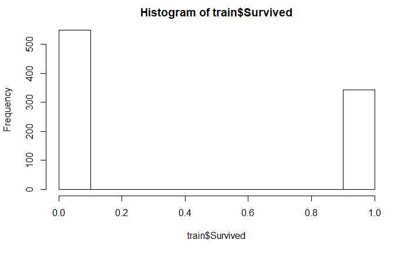

```r
hist(train$Survived)
```

From the plot, most passengers are dead in the training set.

Let’s take a look at the Pclass (ticket class) variable by using a histogram.

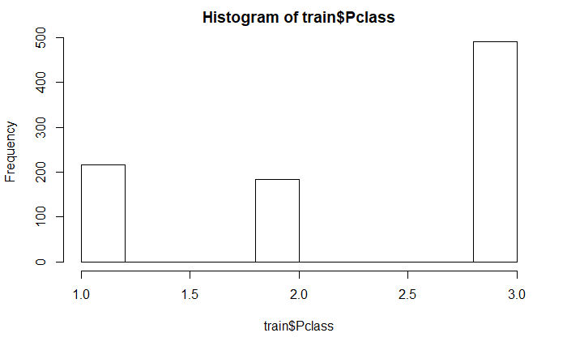

```r
hist(train$Pclass)
```

Most passengers picked the third class for their tickets.

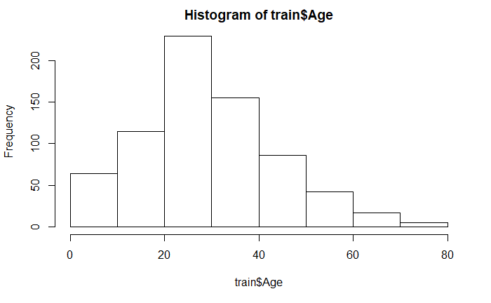

```r
hist(train$Age)
```

Most passengers fall in 20 to 40 years old. There are 177 values (~ 20%) missing in this variable and this will need to be dealt with separately.

Let’s take a look at the number of siblings.

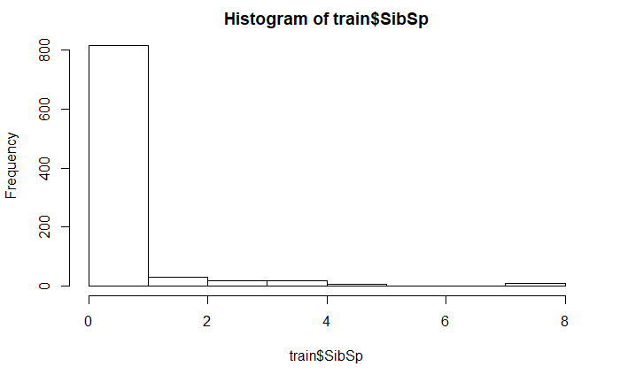

```r
hist(train$SibSp)
```

It turns out that most people did not have any siblings with them. Passengers with more than 4 siblings on board were very rare.

Another variable related to family is the one describing the number of children and parents.

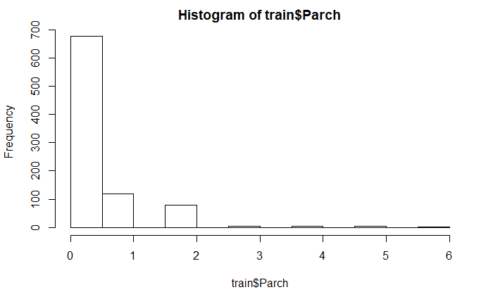

```r
hist(train$Parch)
```

Regarding Fare, let’s see.

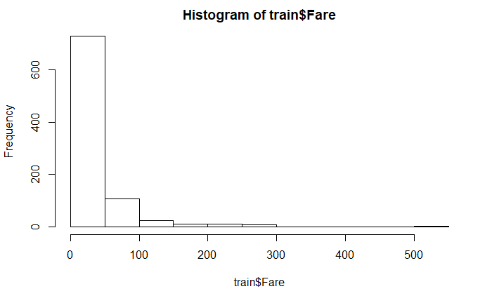

```r
hist(train$Fare)
```

Most people picked cheap tickets.

Since most values in Cabin are missing, this variable is not visualized. Regarding Embarked, since it is a qualitative variable, it will be visualized by using a barplot.

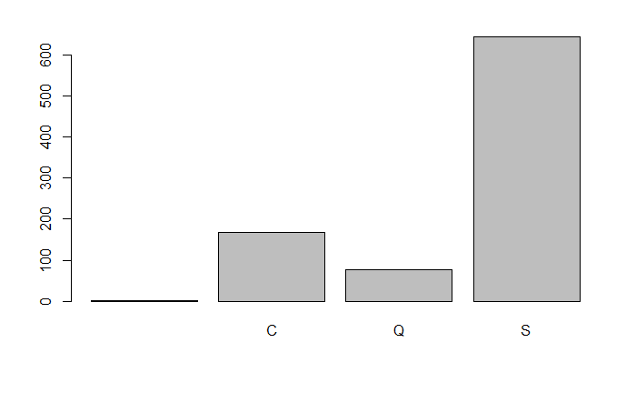

```r
barplot(table(train$Embarked))
```

```r
train <- train[!is.na(train$Embarked),]
rownames(train) <- NULL
#Check for missing values in the Embarked variable
table(is.na(train$Embarked))
```

```
FALSE
  891
```

Now I need to deal with the missing values in the Age variable. Several points to note:

1. Simple missing value imputation with mean/median/mode is not a good way to solve this problem because this can change the variance of Age. Moreover, this oversimplified approach does not produce any realistic estimates.
2. Linear regression is a more sophisticated approach in order to impute missing values. However, it assumes the values are normally distributed. I am going to perform a statistical test for normality (Shapiro-Wilk Normality Test) for Age.

```r
shapiro.test(train$Age)
```

```
    Shapiro-Wilk normality test

data:  train$Age
W = 0.98146, p-value = 7.337e-08
```

For Shapiro-Wilk normality test, H_0: The population is normally distributed. H_a: The population is not normally distributed.

Since the p-value is < 0.05 (at 95% confidence interval), the null hypothesis is rejected. Thus, the variables in Age are not normally distributed.

Thus, imputing the missing values in Age is not a good way out. Imputing the missing values in Age using linear regression may yield unrealistic estimates.

3. kNN (k Nearest Neighbour) is a good way out in this case because it does not assume any distribution of data. It imputes a missing value based on distance between a missing value and its k nearest neighbour. In order to perform kNN imputation, the VIM R library is loaded.

```r
#Load the VIM library
library("VIM")
# An empirical rule to choose the number k is to take the square root of the number of #training samples.
# The number of existing data entries in Age = 891 - 177 = 714. Square root (714) = 26
#
# kNN imputation
train <- kNN(train, variable ="Age", k = 26)
table(is.na(train.imp$Age))
```

[output not shown]

There are no missing values in Age now. A good imputation would make no change to the population distribution. Let’s visualize the distribution of Age after missing values imputation.

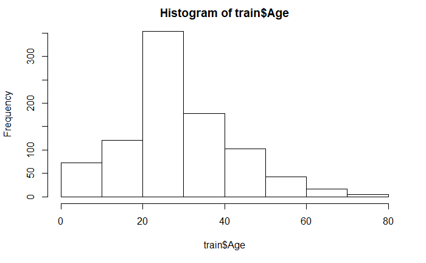

```r
hist(train$Age)
```

The distribution after imputation is essentially the same as that before imputation. I will perform a statistical test to make sure that the population distribution remains as a non-normal distribution.

```r
shapiro.test(train$Age)
```

```
    Shapiro-Wilk normality test

data:  train$Age
W = 0.97377, p-value = 1.4e-11
```

The p-value is <0.05, so the null hypothesis is rejected. The Age population is not normally distributed.

Since not all variables are going to be included in model building, I build another data frame to store the required variables for modeling in ‘train.red’.

```r
train.red <- subset(train, select = c(Survived,Pclass, Sex, Age, SibSp, Parch, Fare, Embarked))
colnames(train.red)
```

```
[1] "Survived" "Pclass"   "Sex"      "Age"      "SibSp"    "Parch"    "Fare"
[8] "Embarked"
```

These are the variables which are required in my model.

## Model Building

### Logistic Regression

I will perform the survival prediction using logistic regression because it is very good at performing binary classification. In order to do so, I will need to train my model. Thus, I will split the data in train.csv into training set (80%) and testing set (20%) in order to validate the model.

```r
train.model <- train.red[1:712,]
test.model <- train.red[713:891,]
```

Applying the logistic regression model to the train.model

```r
model <- glm(Survived ~ ., family=binomial(link='logit'), data=train.model)
summary(model)
```

```
Call:
glm(formula = Survived ~ ., family = binomial(link = "logit"),
    data = train.model)

Deviance Residuals:
    Min       1Q   Median       3Q      Max
-2.6484  -0.6110  -0.4122   0.6453   2.4668

Coefficients:
              Estimate Std. Error z value Pr(>|z|)
(Intercept)  1.652e+01  5.354e+02   0.031  0.97539
Pclass      -1.244e+00  1.716e-01  -7.251 4.12e-13 ***
Sexmale     -2.686e+00  2.238e-01 -12.001  < 2e-16 ***
Age         -4.513e-02  9.209e-03  -4.901 9.56e-07 ***
SibSp       -3.324e-01  1.234e-01  -2.693  0.00708 **
Parch       -1.647e-01  1.407e-01  -1.170  0.24196
Fare         1.155e-04  2.680e-03   0.043  0.96563
EmbarkedC   -1.075e+01  5.354e+02  -0.020  0.98398
EmbarkedQ   -1.071e+01  5.354e+02  -0.020  0.98404
EmbarkedS   -1.106e+01  5.354e+02  -0.021  0.98352
---
Signif. codes:  0 ‘***’ 0.001 ‘**’ 0.01 ‘*’ 0.05 ‘.’ 0.1 ‘ ’ 1

(Dispersion parameter for binomial family taken to be 1)

    Null deviance: 952.58  on 711  degrees of freedom
Residual deviance: 634.80  on 702  degrees of freedom
AIC: 654.8

Number of Fisher Scoring iterations: 12
```

Test for significance of the overall regression In this section, the significance of the overall regression was tested by using the difference between null deviance and residual deviance to obtain the p-value.

```r
1-pchisq(317.78,9)
```

```
[1] 0
```

Since the p-value is 0, the overall regression is significance.

### Model Fit Assessment

Goodness of Fit Hypothesis Testing Using deviance residual

```r
c(deviance(model), 1-pchisq(deviance(model),702))
```

```
[1] 634.7977051   0.9668369
```

Since the p-value > 0.5, the null hypothesis must be accepted. This indicates that the fitting is a good fit.

Assessing the goodness of fit using Pearson residuals

```r
## Using Pearson residuals
pearson_residuals <- residuals(model, type="pearson")
pearson_residuals.tvalue <- sum(pearson_residuals^2)
c(pearson_residuals.tvalue, 1-pchisq(pearson_residuals.tvalue,702))
```

```
[1] 737.5550051   0.1707896
```

### Cross Validation Using Data in test.model

```r
prediction <- predict(model, newdata = test.model, type='response')
prediction <- ifelse(prediction > 0.5, 1,0) #0.5 as the threshold value
```

Performance assessment using a confusion matrix as provided in the caret R package

```r
library("caret")
library("e1071")
confusionMatrix(data=prediction, reference=test.model$Survived)
```

```
Confusion Matrix and Statistics

          Reference
Prediction   0   1
         0 103  17
         1  12  47

               Accuracy : 0.838
                 95% CI : (0.7757, 0.8887)
    No Information Rate : 0.6425
    P-Value [Acc > NIR] : 5.581e-09

                  Kappa : 0.6411
 Mcnemar's Test P-Value : 0.4576

            Sensitivity : 0.8957
            Specificity : 0.7344
         Pos Pred Value : 0.8583
         Neg Pred Value : 0.7966
             Prevalence : 0.6425
         Detection Rate : 0.5754
   Detection Prevalence : 0.6704
      Balanced Accuracy : 0.8150

       'Positive' Class : 0
```

The accuracy of the logistic regression model is about 84%, which is quite good.

Another way to assess the prediction performance is to employ the ROC curve using the ROCR library.

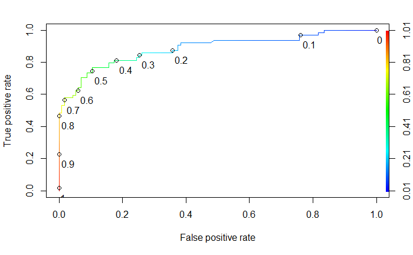

```r
library(ROCR)
predictions <- predict(model, newdata=test.model, type="response")
pred <- prediction(predictions, test.model$Survived)
perf <- performance(pred, measure = "tpr", x.measure = "fpr")
plot(perf, colorize = TRUE, text.adj = c(-0.2,1.7), print.cutoffs.at = seq(0,1,0.1))
```

A ROC plot is obtained by plotting the true positive rate and the false positive rate. By computing the area under the ROC curve (AUC), an indicator of the reliability of the prediction can be obtained.

```r
auc <- performance(pred, measure = "auc")
auc <- auc@y.values[[1]]
auc
```

```
[1] 0.8855299
```

An AUC value of 1 is ideal. In this case, the AUC value is 0.89, which is very close to 1. Thus, this model comes with good predictability.

### Prediction with the new set data

Selecting the required variables for survival prediction

```r
test.data <- subset(test, select = c(2,4,5,6,7,9,11))
colnames(test.data)
```

```
[1] "Pclass"   "Sex"      "Age"      "SibSp"    "Parch"    "Fare"     "Embarked"
```

```r
summary(test.data)
```

```
     Pclass          Sex           Age            SibSp            Parch
 Min.   :1.000   female:152   Min.   : 0.17   Min.   :0.0000   Min.   :0.0000
 1st Qu.:1.000   male  :266   1st Qu.:21.00   1st Qu.:0.0000   1st Qu.:0.0000
 Median :3.000                Median :27.00   Median :0.0000   Median :0.0000
 Mean   :2.266                Mean   :30.27   Mean   :0.4474   Mean   :0.3923
 3rd Qu.:3.000                3rd Qu.:39.00   3rd Qu.:1.0000   3rd Qu.:0.0000
 Max.   :3.000                Max.   :76.00   Max.   :8.0000   Max.   :9.0000
                              NA's   :86
      Fare         Embarked
 Min.   :  0.000   C:102
 1st Qu.:  7.896   Q: 46
 Median : 14.454   S:270
 Mean   : 35.627
 3rd Qu.: 31.500
 Max.   :512.329
 NA's   :1
```

There are 86 missing values in Age and 1 missing value in Fare. Again, kNN imputation will be used for imputing missing values in Age.

Visualizing the distribution of Age in test.data before missing values imputation

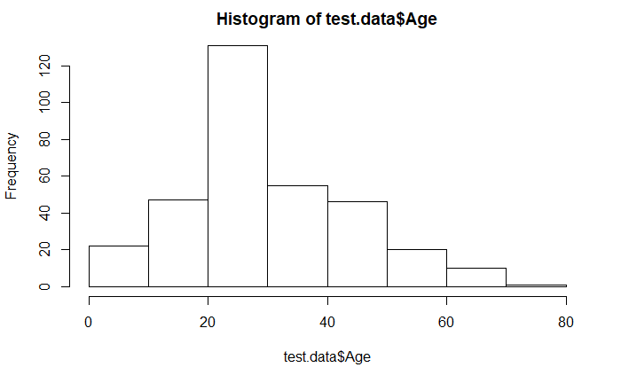

```r
hist(test.data$Age)
```

```r
test.data <- kNN(test.data, variable ="Age", k = 20)
table(is.na(test.data$Age))
```

```
FALSE
  418
```

There are no more missing values in Age. Let’s visualize the population distribution of Age after missing values imputation.

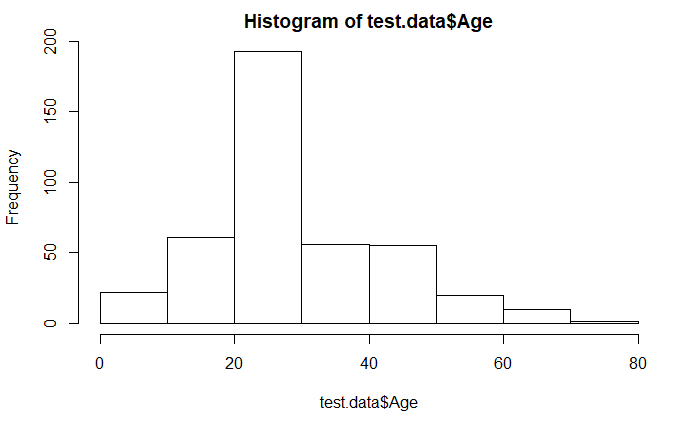

```r
hist(test.data$Age)
```

The distribution of Age is roughly the same before and after missing values imputation.

Predicting survival data for passengers in test.data

```r
#Ignore the 1 missing variable in Fare
test.data <- test.data[!is.na(test.data$Fare),]
rownames(test.data) <- NULL
#Predict
testdatapre <-predict(model, newdata=test.data, type="response")
testprefinal <- ifelse(testdatapre > 0.5, 1,0)
testprefinal
```

```
  1   2   3   4   5   6   7   8   9  10  11  12  13  14  15  16  17  18  19  20  21  22
  0   0   0   0   1   0   1   0   1   0   0   0   1   0   1   1   0   0   1   0   0   0
 23  24  25  26  27  28  29  30  31  32  33  34  35  36  37  38  39  40  41  42  43  44
  1   1   1   0   1   0   0   0   0   0   0   1   1   0   1   1   0   0   0   0   0   1
 45  46  47  48  49  50  51  52  53  54  55  56  57  58  59  60  61  62  63  64  65  66
  1   0   0   0   1   0   1   0   1   1   0   0   0   0   0   1   0   0   0   1   1   1
 67  68  69  70  71  72  73  74  75  76  77  78  79  80  81  82  83  84  85  86  87  88
  1   0   1   1   1   0   1   1   1   1   0   1   0   1   0   0   0   0   0   0   1   1
 89  90  91  92  93  94  95  96  97  98  99 100 101 102 103 104 105 106 107 108 109 110
  1   0   1   0   1   0   1   0   1   0   1   0   1   0   0   0   1   0   0   0   0   0
111 112 113 114 115 116 117 118 119 120 121 122 123 124 125 126 127 128 129 130 131 132
  0   1   1   1   1   0   0   1   1   1   1   0   1   0   0   1   0   1   0   0   0   0
133 134 135 136 137 138 139 140 141 142 143 144 145 146 147 148 149 150 151 152 153 154
  0   0   0   0   0   0   1   0   0   1   0   0   0   0   0   0   0   0   1   0   0   0
155 156 157 158 159 160 161 162 163 164 165 166 167 168 169 170 171 172 173 174 175 176
```

[output cut: 23 more lines]

```r
table(testprefinal)
```

```
testprefinal
  0   1
259 158
```

Finally, I would like to output the prediction results to titanic_prediction_results.csv file.

```r
#Remove the row where Fare has a missing value
test <- test[!is.na(test$Fare),]
rownames(test) <- NULL
export <- data.frame(PassengerID = test$PassengerId, Survived = testprefinal)
write.csv(export, file = 'titanic_prediction_results.csv', row.names = F)
```